# Kickstarted?: Predicting the Success of Kickstarter Projects Using Machine Learning

Joshua Davis

May 18, 2018

# 1 Introduction

We will be using machine learning in an effort to predict the success or failure of Kickstarter projects. The general question we hope to answer is: Given certain factors, such as goal (how much money the Kickstarter project wants to raise) and duration (for how long can people back the project), can we predict if the project will be successful or not? We will define success later. We will also be doing some exploratory data analysis and visualization throughout. We will train and/or analyze multiple machine learning models, tune hyperparameters, and compare their results.

Our tasks are as follows:

1. Load our data
2. Tidy our data
3. Perform some EDA and visualization
4. Train and analyze our machine learning models

## 1.1 Load Libraries

Below you can see the libraries we used to perform our data analysis…

```r
library(lubridate)
library(dplyr)
library(knitr)
library(ggplot2)
library(randomForest)
library(caret)
library(purrr)
library(tidyr)
library(broom)
library(ROCR)
library(cvTools)
```

# 2 Data

Below we load our primary table obtained from https://www.kaggle.com/kemical/kickstarter-projects. The data originates from https://www.kickstarter.com. Kickstarter is one of many ‘crowdfunding’ sites where entrepreneurs can fund projects with the help of other people.

*Also, please excuse any profanity in the names of projects as I did not create them.*

## 2.1 Loading

```r
projects <- read.csv("ks-projects-201801.csv", stringsAsFactors = FALSE)

str(projects)
```

```
## 'data.frame':    378661 obs. of  15 variables:
##  $ ID              : int  1000002330 1000003930 1000004038 1000007540 1000011046 1000014025 1000023410 1000030581 1000034518 100004195 ...
##  $ name            : chr  "The Songs of Adelaide & Abullah" "Greeting From Earth: ZGAC Arts Capsule For ET" "Where is Hank?" "ToshiCapital Rekordz Needs Help to Complete Album" ...
##  $ category        : chr  "Poetry" "Narrative Film" "Narrative Film" "Music" ...
##  $ main_category   : chr  "Publishing" "Film & Video" "Film & Video" "Music" ...
##  $ currency        : chr  "GBP" "USD" "USD" "USD" ...
##  $ deadline        : chr  "2015-10-09" "2017-11-01" "2013-02-26" "2012-04-16" ...
##  $ goal            : num  1000 30000 45000 5000 19500 50000 1000 25000 125000 65000 ...
##  $ launched        : chr  "2015-08-11 12:12:28" "2017-09-02 04:43:57" "2013-01-12 00:20:50" "2012-03-17 03:24:11" ...
##  $ pledged         : num  0 2421 220 1 1283 ...
##  $ state           : chr  "failed" "failed" "failed" "failed" ...
##  $ backers         : int  0 15 3 1 14 224 16 40 58 43 ...
##  $ country         : chr  "GB" "US" "US" "US" ...
##  $ usd.pledged     : num  0 100 220 1 1283 ...
##  $ usd_pledged_real: num  0 2421 220 1 1283 ...
##  $ usd_goal_real   : num  1534 30000 45000 5000 19500 ...
```

Most of the attributes do not need an explaination. It should be noted that the ‘goal’, ‘pledged’ and ‘usd.pledged’ variables will be dropped in tidying because of differences in currency and currency conversion. Attributes usd_pledged_real and usd_goal_real are conversions of pledged and goal by the authors of the dataset using [Fixer.io API](https://fixer.io/) in order to have accurate and uniform conversions.

## 2.2 Tidying

Our dataset is a mostly “tidy” dataset. However, we must still perform some transformations for our purposes.

As menioned in the loading section, we must drop attributes ‘goal’, ‘pledged’ and ‘usd.pledged’. We must also convert ‘launched’ and ‘deadline’ into datetime, as well as add a variable ‘duration’ that equals ‘deadline’ - ‘launched’. Additionally, we will convert categorical attributes into factors. For simplicity we will also turn this into a binary classification problem (i.e. ‘state’ equals ‘0’ or ‘1’). It may be interesting to explore muticlass prediction later on if time permits.

### 2.2.1 Drop Unused Attributes

We start our transformations by dropping ‘goal’, ‘pledged’ and ‘usd.pledged’.

```r
projects <- projects %>%
  select(-goal, -pledged, -usd.pledged)
```

### 2.2.2 Conversions

Next we will make our conversions for time and categorical attributes.

```r
projects$launched <- ymd_hms(projects$launched)
projects$deadline <- ymd(projects$deadline)

projects$main_category <- as.factor(projects$main_category)
projects$category <- as.factor(projects$category)
projects$currency <- as.factor(projects$currency)
projects$country <- as.factor(projects$country)
#projects$state should also be a factor, but we address this in the next subsection.
```

### 2.2.3 Duration & Label Translation

Now lets add an attribute ‘duration’ that equals ‘deadline’ - ‘launched’

```r
projects <- projects %>%
  mutate(duration = difftime(deadline, launched, units = "secs")) %>%
  transform(duration = as.numeric(duration))
```

Finally we take a look at the state attribute…

```r
levels(as.factor(projects$state))
```

```
## [1] "canceled"   "failed"     "live"       "successful" "suspended"
## [6] "undefined"
```

This means we must come up with a measure of success (‘1’) and failure (‘0’) ourselves. We will define success as ‘usd_pledged_real’ - ‘usd_goal_real’ >= 0. Translation below…

```r
projects <- projects %>%
  mutate(state = ifelse(usd_pledged_real - usd_goal_real >= 0, 1, 0))

projects$state <- as.factor(projects$state)

str(projects)
```

```
## 'data.frame':    378661 obs. of  13 variables:
##  $ ID              : int  1000002330 1000003930 1000004038 1000007540 1000011046 1000014025 1000023410 1000030581 1000034518 100004195 ...
##  $ name            : chr  "The Songs of Adelaide & Abullah" "Greeting From Earth: ZGAC Arts Capsule For ET" "Where is Hank?" "ToshiCapital Rekordz Needs Help to Complete Album" ...
##  $ category        : Factor w/ 159 levels "3D Printing",..: 109 94 94 91 56 124 59 42 114 40 ...
##  $ main_category   : Factor w/ 15 levels "Art","Comics",..: 13 7 7 11 7 8 8 8 5 7 ...
##  $ currency        : Factor w/ 14 levels "AUD","CAD","CHF",..: 6 14 14 14 14 14 14 14 14 14 ...
##  $ deadline        : Date, format: "2015-10-09" "2017-11-01" ...
##  $ launched        : POSIXct, format: "2015-08-11 12:12:28" "2017-09-02 04:43:57" ...
##  $ state           : Factor w/ 2 levels "0","1": 1 1 1 1 1 2 2 1 1 1 ...
##  $ backers         : int  0 15 3 1 14 224 16 40 58 43 ...
##  $ country         : Factor w/ 23 levels "AT","AU","BE",..: 10 23 23 23 23 23 23 23 23 23 ...
##  $ usd_pledged_real: num  0 2421 220 1 1283 ...
##  $ usd_goal_real   : num  1534 30000 45000 5000 19500 ...
##  $ duration        : num  5053652 5166963 3886750 2579749 4807497 ...
```

This completes our tidying.

Pragmatically speaking, a project that reaches its goal but does not deliver their product, or is otherwise cancelled / delayed et cetra could be considered a failure to the consumer. This is where one could deploy a model amenable to a multiclass setting. I have deemed our data insufficent to make accurate predictions in such a setting. One can hope for more information on the project teams, such as prior successes. This consideration is the reason for simplifying to a binary setting. Therefore, our prediction ability would be mainly useful to other project teams who are looking to reach a certain goal for their Kickstarter projects.

# 3 Exploratory Data Analysis and Visualization

Since our ultimate goal is prediction using machine learning models, it would be helpful to try and get a sense of what attributes may have a large impact on predicting ‘1’ (success) or ‘0’ (failure).

## 3.1 Setup

We will start by partitioning our main table into two intermediate tables, one for successes and one for failures. This way we can perform EDA separately and easily.

```r
successes <- projects %>%
  filter(state == 1)

failures <- projects %>%
  filter(state == 0)
```

```r
kable(head(successes))
```

| ID | name | category | main_category | currency | deadline | launched | state | backers | country | usd_pledged_real | usd_goal_real | duration |
| --- | --- | --- | --- | --- | --- | --- | --- | --- | --- | --- | --- | --- |
| 1000014025 | Monarch Espresso Bar | Restaurants | Food | USD | 2016-04-01 | 2016-02-26 13:38:27 | 1 | 224 | US | 52375.0 | 50000.00 | 2974893 |
| 1000023410 | Support Solar Roasted Coffee & Green Energy! SolarCoffee.co | Food | Food | USD | 2014-12-21 | 2014-12-01 18:30:44 | 1 | 16 | US | 1205.0 | 1000.00 | 1661356 |
| 100005484 | Lisa Lim New CD! | Indie Rock | Music | USD | 2013-04-08 | 2013-03-09 06:42:58 | 1 | 100 | US | 12700.0 | 12500.00 | 2567822 |
| 1000057089 | Tombstone: Old West tabletop game and miniatures in 32mm. | Tabletop Games | Games | GBP | 2017-05-03 | 2017-04-05 19:44:18 | 1 | 761 | GB | 121857.3 | 6469.73 | 2348142 |
| 1000070642 | Mike Corey’s Darkness & Light Album | Music | Music | USD | 2012-08-17 | 2012-08-02 14:11:32 | 1 | 7 | US | 250.0 | 250.00 | 1244908 |
| 1000072011 | CMUK. Shoes: Take on Life Feet First. | Fashion | Fashion | USD | 2013-12-30 | 2013-11-25 07:06:11 | 1 | 624 | US | 34268.0 | 20000.00 | 2998429 |

```r
kable(head(failures))
```

| ID | name | category | main_category | currency | deadline | launched | state | backers | country | usd_pledged_real | usd_goal_real | duration |
| --- | --- | --- | --- | --- | --- | --- | --- | --- | --- | --- | --- | --- |
| 1000002330 | The Songs of Adelaide & Abullah | Poetry | Publishing | GBP | 2015-10-09 | 2015-08-11 12:12:28 | 0 | 0 | GB | 0 | 1533.95 | 5053652 |
| 1000003930 | Greeting From Earth: ZGAC Arts Capsule For ET | Narrative Film | Film & Video | USD | 2017-11-01 | 2017-09-02 04:43:57 | 0 | 15 | US | 2421 | 30000.00 | 5166963 |
| 1000004038 | Where is Hank? | Narrative Film | Film & Video | USD | 2013-02-26 | 2013-01-12 00:20:50 | 0 | 3 | US | 220 | 45000.00 | 3886750 |
| 1000007540 | ToshiCapital Rekordz Needs Help to Complete Album | Music | Music | USD | 2012-04-16 | 2012-03-17 03:24:11 | 0 | 1 | US | 1 | 5000.00 | 2579749 |
| 1000011046 | Community Film Project: The Art of Neighborhood Filmmaking | Film & Video | Film & Video | USD | 2015-08-29 | 2015-07-04 08:35:03 | 0 | 14 | US | 1283 | 19500.00 | 4807497 |
| 1000030581 | Chaser Strips. Our Strips make Shots their B*tch! | Drinks | Food | USD | 2016-03-17 | 2016-02-01 20:05:12 | 0 | 40 | US | 453 | 25000.00 | 3815688 |

### 3.1.1 One Quick Note

```r
nrow(failures) / nrow(successes)
```

```
## [1] 1.763102
```

This is the ratio of failures to successes. The failures well outnumber the successes, which could be an indicator that being successful is a rare event. One should keep this in mind when viewing the graphs in this section. It will become particularly important in the machine learning section when we must decide how to evaluate our models.

## 3.2 Comparing Attributes

### 3.2.1 Main Category

Lets first take a look at what category of project has the most successes and what category has the most failures. We look at main category here because R’s randomForest cannot handle categorical variables with more than 53 categories (i.e. the ‘category’ attribute).

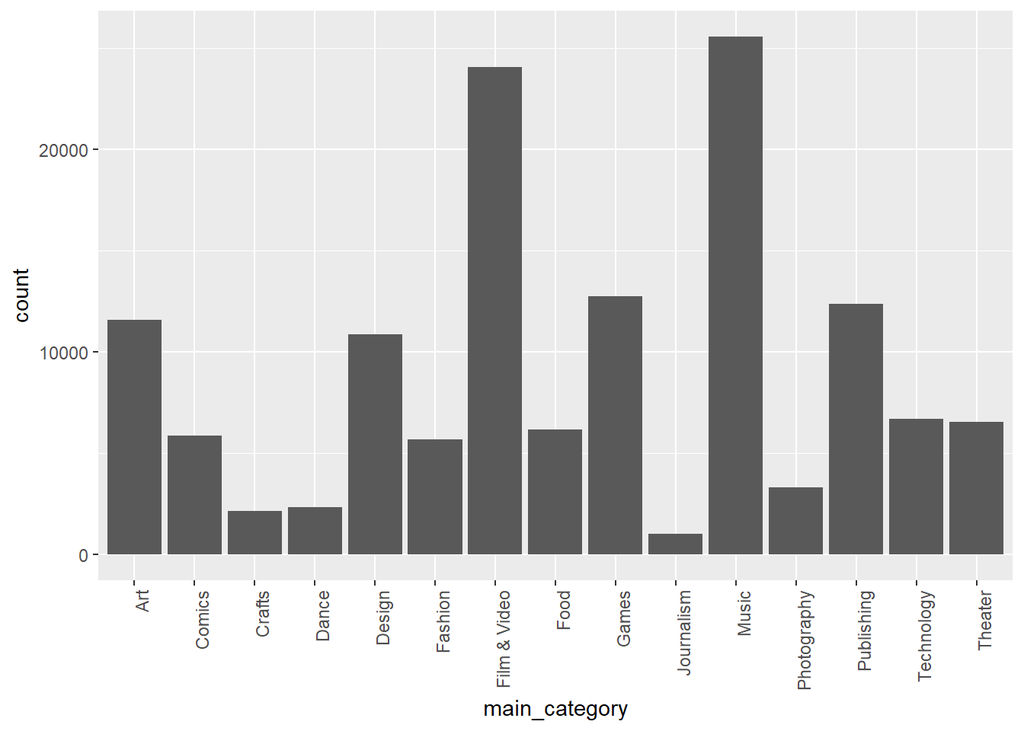

```r
successes %>%
  ggplot(aes(x = main_category)) +
  geom_histogram(stat = "count") +
  theme(axis.text.x = element_text(angle = 90, hjust = 1))
```

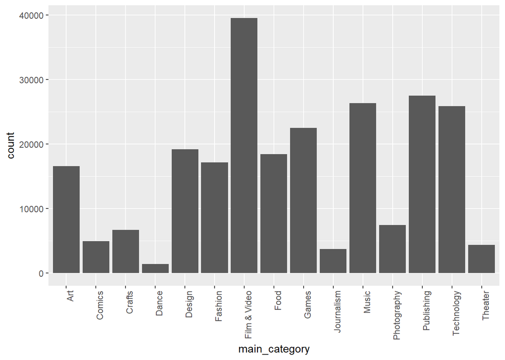

```r
failures %>%
  ggplot(aes(x = main_category)) +
  geom_histogram(stat = "count") +
  theme(axis.text.x = element_text(angle = 90, hjust = 1))
```

Keeping in mind that failures outnumber successes by a factor of ~1.7, music stands out as a particularly successful category. Lets check music’s ratio…

```r
nrow(filter(failures, main_category == "Music")) /
  nrow(filter(successes, main_category == "Music"))
```

```
## [1] 1.030982
```

As opposed to many other categories, music has almost a 1 to 1 ratio of failures to successes.

### 3.2.2 Goal

One might assume that projects with a prohibitivly high goal would be unlikely to be successful. Lets start by seeing if we can spot a difference…

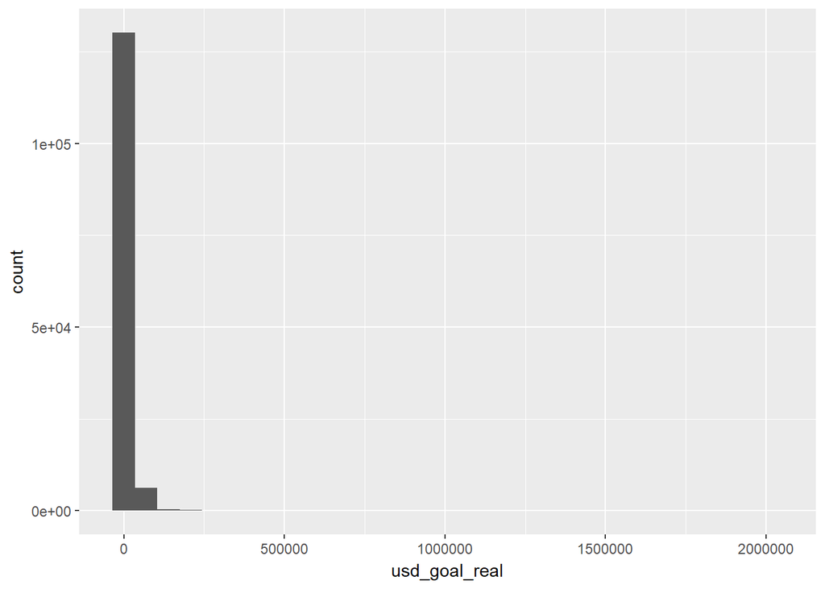

```r
successes %>%
  ggplot(aes(x = usd_goal_real)) +
  geom_histogram()
```

It is not easy to see the distribution of goals for successes here. A simple transformation can fix this…

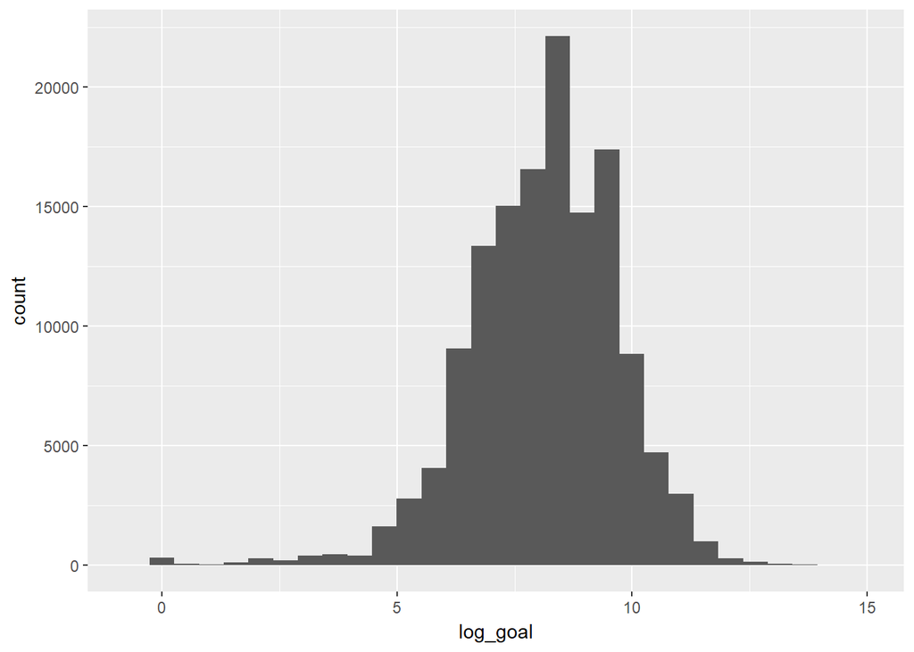

```r
successes %>%
  mutate(min_goal = min(usd_goal_real)) %>%
  mutate(log_goal = log(usd_goal_real - min_goal)) %>%
  ggplot(aes(x = log_goal)) +
  geom_histogram()
```

Much better.

Now lets take a look at the failures (after performing the same transformation as we did for successes)…

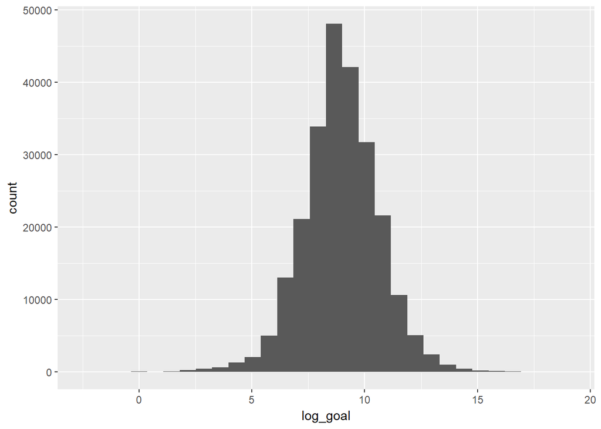

```r
failures %>%
  mutate(min_goal = min(usd_goal_real)) %>%
  mutate(log_goal = log(usd_goal_real - min_goal)) %>%
  ggplot(aes(x = log_goal)) +
  geom_histogram()
```

(The min_goal happens to be the same for both successes and failures.)

The distributions seem fairly similar. For good measure lets take a look at them side by side…

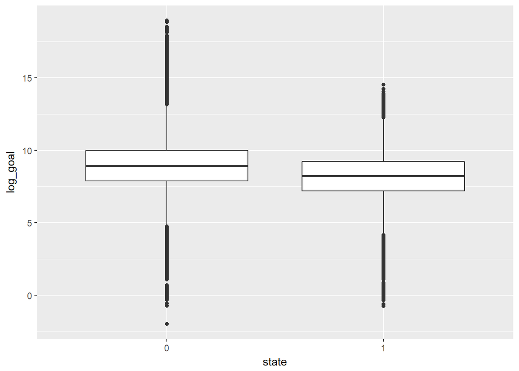

```r
projects %>%
  mutate(min_goal = min(usd_goal_real)) %>%
  mutate(log_goal = log(usd_goal_real - min_goal)) %>%
  ggplot(aes(x = state, y = log_goal)) +
  geom_boxplot()
```

While failures definitly have higher goals on average, it seems premature to conclude that the goal will have a significant affect on the success of a project.